# Visualisation avec

### Les scripts R

- Ils permettent de **garder la trace** du processus de création de chaque variable, tableau, figure, etc., ce qui permet de refaire les traitements dans leur globalité
- Ils sont **facilement partageables** avec d’autres, sous réserve de respecter des pratiques de “bon” usage
  - coder de façon compréhensible avec des commentaires et en documentant ses fonctions
  - donner des noms explicites aux objets et fonctions
  - utiliser les conventions de nommage, notamment pour distinguer les variables d’origine des variables créées
- Pour les **variables**, utiliser un **nom**  
  *Exemple* : `temperature_max`
- Pour les **fonctions**, utiliser un **verbe**  
  *Exemple* : `create.map` serait une fonction qui permettrait de créer une carte
- Pour **distinguer variables d’origine / variables recodées**, on peut utiliser un préfixe ou un suffixe  
  *Exemple* : `age` est la variable d’origine et `age_recod` est la variable recodée

**NoteLes conventions de nommage**

Il existe différentes conventions

- **`allowercase`** : tout en minuscule, sans séparateur
- **`period.separated`** : tout en minuscule, mots séparés par des points
- **`underscore_separated`** : tout en minuscule, mots séparés par un *underscore* (`_`)
- **`lowerCamelCase`** : première lettre des mots en majuscule, à l’exception du premier mot ; et si nom simple, tout en minuscule
- **`UpperCamelCase`** : première lettre des mots en majuscule, y compris le premier et même lorsque le nom est composé d’un seul mot

**Possibilité de mixer les conventions mais en gardant une cohérence afin de faciliter la compréhension des fichiers et du code**

**R est sensible à la casse** ce qui signifie que `variable` et `Variable` sont deux objets différents

#### Comment organiser ses scripts ?

- Utiliser une **convention de dénomination des fichiers** et donner des **noms explicites**
- **Séparer les traitements**
  - import et préparation des données (nettoyage, fusion, filtrage)
  - traitement statistique
    - analyses univariées
    - analyses bivariées
    - analyses multivariées/modélisation
  - production des résultats, rapports

**AstuceComment nommer ses scripts ?**

- Une “bonne” pratique consiste à utiliser la structure `numero_nom_millesime.extension`
- Le nom ne doit contenir ni caractères spéciaux (``-.,;:\/$^`) ni caractères accentués  
  *Exemple* : `01_import_donnees_20250606.R` ; `02_nettoyage_donnees_20250610.R` ; `03_analyses_univariees_20250701.R`

**NoteRessources sur le processus d’analyse et de communication des données reproductibles**

[R Workflow](https://hbiostat.org/rflow)

[Reproducible analytical pipeline](https://raps-with-r.dev/)

#### Comment structurer ses scripts ?

1. Commencer l’écriture du script par les **métadonnées** (titre, auteur, date, version de R, encodage, etc.)

[figure not shown]

2. Lister les **packages** utilisés, au début des scripts, pour les identifier plus rapidement, en notant leur version
- manuellement

```r
library(tidyverse)    # v2.0.0
library(questionr)    # v0.8.2
```

- de façon automatisée

```r
packages_utilises <- sessionInfo()
```

3. **Structurer** en parties et sous-parties, facilement grâce à l’*addin* `strcode`

```r
#   ____________________________________________
#   Titre 1                                 ####
##  ............................................
##  Titre 2                                 ####
```

*Installation : `remotes::install_github("lorenzwalthert/strcode")`*

4. **Commenter** les scripts, en particulier pour expliquer les étapes-clés (= une aide pour les autres, mais aussi pour soi, pour plus tard)

**NoteLe préfixage**

La notation

```r
dplyr::filter(Journals, field == "Econometrics")
```

peut remplacer le code

```r
library(dplyr)
filter(Journals, field == "Econometrics")
```

**Avantages**

- Évite les conflits si plusieurs packages ont une fonction avec le même nom (mais des paramètres différents)  
  *Exemple* : la fonction `filter()` existe dans les packages {stats} et {dplyr}
- Identifie le package d’où provient une fonction
- Ne charge pas la totalité d’un package pour n’utiliser qu’une seule de ses fonctions

**AstuceAide pour écrire les scripts**

Activer les options de diagnostic pour signaler les erreurs dans les scripts sous RStudio : `Tools > Global Options > Code > Diagnostics`

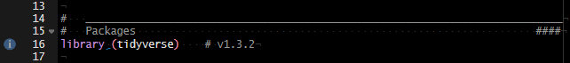

package [{styler}](https://github.com/r-lib/styler) : mettre en forme le code selon le [Tidyverse Style Guide](https://style.tidyverse.org/index.html) (ou selon son propre style)

package [{lintr}](https://lintr.r-lib.org/) : vérifier que le code est conforme à un guide de style donné

### Le fichier README

Ce fichier, généralement un fichier au format .txt ou .md (markdown), qui présente le **projet**, sa **structuration** et les **étapes d’exécution des différents script** pour comprendre, reproduire et utiliser le projet, est à placer dans le dossier du projet

**Exemple de fichier README**

```markdown
# VisuR_2026

Projet du cours "Visualisation des données sous R" pour l'année universitaire 2026-2027

## Structure
- data/ : données
    ├── sources/ : données sources, données brutes
    └── produites/ : données produites
- scripts/ : scripts R, qmd
- outputs/ : graphiques et tableaux exportés
- docs/ : rapports et supports

## Comment reproduire les analyses
1. Ouvrir le projet `VisuR_2026.Rproj`
2. Exécuter les scripts dans l'ordre (01_import.R, 02_nettoyage.R, etc.)
3. Les graphiques générés sont enregistrés dans le dossier outputs
4. Le rapport d'étude est enregistré dans le dossier docs
```

### Citer la version de R ainsi que les packages que vous avez utilisés dans vos travaux

**Avec la fonction `citation()`**

#### Pour citer la version de R

**Afficher le code**

```r
# Citer R
citation()
```

```
  R Core Team (2026). _R: A Language and Environment for Statistical
  Computing_. R Foundation for Statistical Computing, Vienna, Austria.
  doi:10.32614/R.manuals <https://doi.org/10.32614/R.manuals>.
  <https://www.R-project.org/>.

Une entrée BibTeX pour les utilisateurs LaTeX est

  @Manual{,
    title = {R: A Language and Environment for Statistical Computing},
    author = {{R Core Team}},
    organization = {R Foundation for Statistical Computing},
    address = {Vienna, Austria},
    year = {2026},
    doi = {10.32614/R.manuals},
    url = {https://www.R-project.org/},
  }

We have invested a lot of time and effort in creating R, please cite it
when using it for data analysis. See also 'citation("pkgname")' for
citing R packages.
```

#### Pour citer un package

**Afficher le code**

```r
# Citer un package (ici ggplot2)
citation("ggplot2")
```

```
  H. Wickham. ggplot2: Elegant Graphics for Data Analysis.
  Springer-Verlag New York, 2016.

Une entrée BibTeX pour les utilisateurs LaTeX est

  @Book{,
    author = {Hadley Wickham},
    title = {ggplot2: Elegant Graphics for Data Analysis},
    publisher = {Springer-Verlag New York},
    year = {2016},
    isbn = {978-3-319-24277-4},
    url = {https://ggplot2.tidyverse.org},
  }
```

## À VOUS DE JOUER !

**Exercice 1**

1. Vérifier que [R] et [RStudio] sont installés
2. Définir l’encodage UTF-8
3. Vérifier que le package `{tidyverse}` est installé et l’installer si ce n’est pas le cas

**Quelle est la version de [R] et des packages `{tidyverse}` et `{ggplot2}` que vous utilisez ?**

4. Sous [RStudio], créer un projet nommé **`VisuR_exercices`**
5. Créer les dossiers nécessaires pour une bonne structuration de votre travail
6. Déposer le fichier `communes.csv` dans le dossier adéquat de votre projet
7. Dans votre projet [RStudio], créer un script [R] nommé **`01_Exercices_VisuR.R`**, qui servira pour les exercices à venir, durant lesquels vous aurez besoin des packages `{readr}` et `{dplyr}`
8. Commencer l’écriture de ce script avec ces premiers éléments

*Solution 1*.

**Proposition de structuration du projet**

```markdown
VisuR_exercices/
├── data/
│   ├── sources/
│   │   └── communes.csv
│   └── produites/
├── scripts/
│   └── 01_Exercices_VisuR.R
├── figures/
├── results/
├── README.md
└── VisuR_exercices.Rproj
```

**Script 01_Exercices_VisuR.R**

**Afficher le code**

```r
#   ____________________________________________________________________________
#   Script : Script pour les exercices "VisuR"
#   Auteur : Sandrine Lyser
#   Date   : 02 oct. 2026
#   Dernière modification : sys.date()
#   Text encoding : UTF-8
#   R version : R version 4.6.0 (2026-04-24 ucrt) -- "Because it was There"
#   ____________________________________________________________________________

#   ____________________________________________________________________________
#   Packages                                                                ####

library(readr)    # v2.2.0
library(dplyr)    # v1.2.1
```

## L’univers du `tidyverse`

### Présentation générale et installation

- **Ensemble de packages reprenant des opérations courantes de R, qui partagent une même philosophie et syntaxe pour travailler ensemble et faciliter, la manipulation, l’analyse et la visualisation des données**
- L’accent est mis sur la lisibilité et la chaîne d’opérations, via l’opérateur *pipe* `|>`  
  code dans l’ordre logique des étapes, moins d’objets intermédiaires et de parenthèses imbriquées que dans la syntaxe R de base

La commande `install.packages("tidyverse")` installe simultanément plusieurs packages

- [{dplyr}](https://dplyr.tidyverse.org/) : manipulation des données
- [{forcats}](https://forcats.tidyverse.org/) : traitement des variables qualitatives
- [{ggplot2}](https://ggplot2.tidyverse.org/) : visualisation des données
- [{lubridate}](https://lubridate.tidyverse.org/) : manipulation des dates et heures
- [{purrr}](https://purrr.tidyverse.org/) : programmation
- [{readr}](https://readr.tidyverse.org/) : import de données
- [{stringr}](https://stringr.tidyverse.org/) : manipulation des chaînes de caractères
- [{tibble}](https://tibble.tidyverse.org/) : version modernisée des *dataframes*, plus pratiques à utiliser que les *dataframes* “classiques”
- [{tidyr}](https://tidyr.tidyverse.org/) : nettoyage, remise en forme des données

La commande `library("tidyverse")` charge simultanément ces neuf packages au coeur du tidyverse

[figure not shown]

#### L’opérateur *pipe*

- Opérateur qui permet d’enchaîner des opérations : il prend la sortie d’une fonction (ou d’une expression) et la passe automatiquement comme **premier** argument à la fonction suivante
- Initialement fourni dans le package [{magrittr}](https://magrittr.tidyverse.org/) et noté `%>%`
- Implémenté dans le langage **R** de base depuis la version 4.1.0 et noté `|>`

```r
data |>
  fonction1() |>
  fonction2() |>
  fonction3()
# équivaut à
fonction3(fonction2(fonction1(data)))
```

**Il est recommandé d’utiliser le pipe natif de R** `|>`

**Comment utiliser le pipe natif sous RStudio ?**  
- Allez dans `Tools > Global Options > Code > Editing`  
- Cochez `Use native pipe operator, |> (requires R 4.1+)`

#### Les *tibbles*

- **Version modernisée des *dataframes***, proposée dans le cadre du [`tidyverse`](https://www.tidyverse.org/)
- Plus pratiques à utiliser que les *dataframes* “classiques”
- Plus rapides à manipuler (et plus stables) que les *dataframes*
- Il est possible de convertir d’un type à l’autre
  - *dataframe* $\rightarrow$ *tibble* : avec la fonction `as_tibble()` du package [{tibble}](https://tibble.tidyverse.org/)
  - *tibble* $\rightarrow$ *dataframe* : avec la fonction **R** de base `as.data.frame()`

Pour connaître le type d’objet et savoir si on a un *dataframe* ou un *tibble*, on peut utiliser la fonction `str()`

**NoteAperçu des formats**

##### dataframe

**Afficher le code**

```r
Journals |>
  head(2)
```

```
                                      title                    pub society
1         Asian-Pacific Economic Literature              Blackwell      no
2 South African Journal of Economic History So Afr ec history assn      no
  libprice pages charpp citestot date1 oclc      field
1      123   440   3822       21  1986   14    General
2       20   309   1782       22  1986   59 Ec History
```

##### tibble

**Afficher le code**

```r
Journals |>
  as_tibble() |>
  head(2)
```

```
# A tibble: 2 × 10
  title           pub   society libprice pages charpp citestot date1  oclc field
  <fct>           <fct> <fct>      <int> <int>  <int>    <int> <int> <int> <fct>
1 Asian-Pacific … Blac… no           123   440   3822       21  1986    14 Gene…
2 South African … So A… no            20   309   1782       22  1986    59 Ec H…
```

## Manipulations des données

### Import/Export des données

- Depuis/vers des formats “plats” ou délimités (.csv, .txt)
- Depuis/vers des fichiers Excel ou issus d’autres logiciels de statistique (Stata, SPSS, etc.)
- Depuis/vers des bases de données relationnelles

**AstucePour l’import, bien étudier le jeu de données source, à l’aide des questions suivantes**

1. La première ligne contient-elle le nom des variables ?
2. Quel est le séparateur des colonnes : `,`, `;`, espace(s), `\t` ?
3. Quel est le caractère utilisé pour indiquer les décimales : le point (à l’anglo-saxonne) ou la virgule (à la française) ?
4. Les valeurs textuelles sont-elles encadrées par des guillemets ? Si oui, s’agit-il de guillemets simples (`'`) ou de guillemets doubles (`"`) ?
5. Y a-t-il des valeurs manquantes ? Si oui, comment sont-elles indiquées ?

#### Les fonctions d’import

| Type de fichier | Séparateur de colonnes | Séparateur décimal | Tidyverse | Base R |
| --- | --- | --- | --- | --- |
| Délimité | `,` | `.` | `readr::read_csv()` | `read.csv()` |
|  | `;` | `,` | `readr::read_csv2()` | `read.csv2()` |
|  | un espace (ou plus) | `.` | `readr::read_table()` | `read.table()` |
|  | `\t` | `.` | `readr::read_delim()` | `read.delim()` |
|  | `\t` | `,` | `readr::read_delim2()` | `read.delim2()` |
| Excel |  |  | `readxl::read_excel()` | `xlsx::read.xlsx()` |
| SPSS |  |  | `haven::read_spss()` | `foreign::read.spss()` |
|  |  |  | `haven::read_sav()` |  |
| Stata |  |  | `haven::read_stata()` | `foreign::read.dta()` |
| SAS |  |  | `haven::read_sas()` | `foreign::read.ssd()` |
| dBase |  |  |  | `foreign::read.dbf()` |

#### Les fonctions d’export

| Type de fichier | Tidyverse | Base R |
| --- | --- | --- |
| .txt | `readr::write_delim(delim = "\t")` | `write.table()` |
| .csv | `readr::write_csv()` | `write.csv()` |
| .xlsx | `openxlsx2::write_xlsx()` |  |
|  | `writexl::write_xlsx()` |  |
| .dbf |  | `foreign::write.dbf()` |
| .sav (SPSS) | `haven::write_sav()` | `foreign::write.foreign(package = "SPSS")` |
| .dta (Stata) | `haven::write_dta()` | `foreign::write.dta()` |

#### Exemple d’import pour un fichier .csv

```r
readr::read_csv("file.csv"
                # si la première ligne contient le nom des variables :
                , col_names = TRUE)
```

**AstuceZoom sur la fonction `read_csv2()`**

La fonction `readr::read_csv2()` considère par défaut que le séparateur de colonnes est le point-virgule et que la virgule sert de séparateur décimal

La fonction en langage R de base `read.csv2()` a les mêmes paramètres par défaut

**Utiliser ces fonctions lorsque les fichiers .csv ont ces caractéristiques**

### Manipulations sur les observations et les variables avec le package [{dplyr}](https://dplyr.tidyverse.org/)

**Principales fonctions utiles pour**

- **les lignes/observations**
  - `filter()` : sélectionner/filtrer des observations
  - `distinct`: afficher les observations distinctes
- **les colonnes/variables**
  - `select()` : sélectionner/extraire des variables
  - `mutate()` : créer des variables
  - `relocate()` : changer l’ordre d’une colonne
  - `rename()` : changer le nom des variables

**NoteAide-mémoire des principales fonctions du package {dplyr}**

[*Cheatsheet*](https://rstudio.github.io/cheatsheets/data-transformation.pdf)

#### Filtrer des observations avec la fonction `filter()`

##### Selon un seul critère

**Afficher le code**

```r
# Revues dans le domaine de la Démographie
Journals |>
  dplyr::filter(field == "Demography")
```

```
                              title                pub society libprice pages
30  Journal of Population Economics           Springer      no      411   640
116 Population & Development Review Population Council      no       36   910
137                      Demography   Pop Assn America      no       85   568
    charpp citestot date1 oclc      field
30    3264       69  1987   27 Demography
116   2904      445  1975  218 Demography
137   6859      670  1964  413 Demography
```

##### Selon plusieurs critères

En utilisant les opérateurs logiques

**Afficher le code**

```r
# Revues de Démographie dont l'abonnement coûte moins de 100$
Journals |>
  dplyr::filter(field == "Demography" &
                  libprice < 100)
```

```
                              title                pub society libprice pages
116 Population & Development Review Population Council      no       36   910
137                      Demography   Pop Assn America      no       85   568
    charpp citestot date1 oclc      field
116   2904      445  1975  218 Demography
137   6859      670  1964  413 Demography
```

**NoteOpérateurs logiques les plus courants**

| **Opérateur** | **Description** |
| --- | --- |
| `<` | Inférieur à |
| `<=` | Inférieur ou égal à |
| `>` | Supérieur à |
| `>=` | Supérieur ou égal à |
| `==` | Exactement égal à |
| `!=` | Différent de |
| `\|` | Ou |
| `&` | Et |
| `%in%` | Appartient à |
| `is.na()` | Est une donnée manquante |
| `!is.na()` | N’est pas une donnée manquante |

#### Afficher les valeurs distinctes avec la fonction `distinct()`

On peut afficher les valeurs distinctes selon une (ou plusieurs) variables

**Afficher le code**

```r
# Afficher les valeurs distinctes de 'field'

Journals |>
  distinct(field)
```

```
                 field
1              General
2           Ec History
3          Specialized
4         Area Studies
5    Interdisciplinary
6                Labor
7          Development
11         Consumer Ec
14  Management Science
15             Finance
25           Insurance
28      Public Finance
29  Urban and Regional
30          Demography
32    Ind Organization
36            Business
39        Econometrics
40             Ag Econ
45   Natural Resources
57        Law and Econ
58       International
59      Macroeconomics
84              Theory
123             Health
```

**Cette fonction peut aussi servir à supprimer les doublons dans un jeu de données**

#### Sélectionner des colonnes avec la fonction `select()`

##### Une seule colonne

**Afficher le code**

```r
# Sélection de la variable 'pub'
Journals |>
  dplyr::select(pub)
```

```
                            pub
1                     Blackwell
2        So Afr ec history assn
3                        Kluwer
4                        Kluwer
5                      Elsevier
6                      Elsevier
7           Cambridge Univ Pres
8                      Elsevier
9                        Kluwer
...
```

On peut également utiliser la fonction `pull()` pour sélectionner une (et une seule) colonne

**Afficher le code**

```r
# Sélection de la variable 'pub'
Journals |>
  dplyr::pull(pub)
```

```
  [1] Blackwell                   So Afr ec history assn
  [3] Kluwer                      Kluwer
  [5] Elsevier                    Elsevier
  [7] Cambridge Univ Pres         Elsevier
  [9] Kluwer                      Blackwell
 [11] Kluwer                      MIT
 [13] Blackwell                   Wiley
 [15] Elsevier                    Springer
 [17] MIT Press                   Intnl Atlantic Ec. Soc.
 [19] Sage                        Elsevier
...
```

- Quelle différence avec `select()` ?  
  Le format de sortie est différent :
  - la fonction `select()` renvoie la colonne sous forme de *dataframe*
  - la fonction `pull()` renvoie une colonne sous forme de vecteur

##### Plusieurs colonnes

###### En listant la/les variables à conserver

**Afficher le code**

```r
# Sélection des variables "field" et "libprice"
Journals |>
  dplyr::select(c(field, libprice))
```

```
                 field libprice
1              General      123
2           Ec History       20
...
```

###### En listant la/les variables à supprimer

**Afficher le code**

```r
# Sélection des variables sauf "title" et "pub"
Journals |>
  dplyr::select(-c(title, pub))
```

```
    society libprice pages charpp citestot date1 oclc              field
1        no      123   440   3822       21  1986   14            General
2        no       20   309   1782       22  1986   59         Ec History
...
```

Les tests sur le nom des variables peuvent se faire avec différentes fonctions :

- `contains()`
- `starts_with()`
- `ends_with()`
- `matches()`

**Afficher le code**

```r
# Sélection des variables dont le nom contient "s"
Journals |>
  dplyr::select(contains("s"))
```

```
    society pages citestot
1        no   440       21
...
```

#### Créer/ajouter de nouvelles variables avec `mutate()`

**Afficher le code**

```r
# Ajout de la variable 'anciennete'
Journals |>
  mutate(anciennete = 2026 - date1) -> Journals

names(Journals)
```

```
 [1] "title"      "pub"        "society"    "libprice"   "pages"
 [6] "charpp"     "citestot"   "date1"      "oclc"       "field"
[11] "anciennete"
```

**Penser à affecter la modification au jeu de données**

- La fonction `mutate()` peut également
  - modifier une variable existante si le nom est le même que celui d’une colonne existante
  - supprimer une variable en fixant sa valeur à `NULL`

**Afficher le code**

```r
# Suppression de la variable 'charpp'
Journals |>
  mutate(charpp = NULL) |>
  names()
```

```
 [1] "title"      "pub"        "society"    "libprice"   "pages"
 [6] "citestot"   "date1"      "oclc"       "field"      "anciennete"
```

##### Appliquer des règles conditionnelles

###### La fonction `if_else()`

```r
Journals |>
  mutate(cl_anciennete = if_else(anciennete < 30, " Moins de 30 ans",
                                 if_else(anciennete >= 30  & anciennete < 50, "30 à 49 ans",
                                         if_else(anciennete >= 50 & anciennete < 100, "50 à 99 ans",
                                                 if_else(anciennete >= 100 & anciennete < 150,
                                                         "100 à 149 ans", "150 ans et plus"))))) -> Journals
```

###### La fonction `case_when()`

```r
Journals |>
  mutate(cl_anciennete = case_when(anciennete < 30 ~ "Moins de 30 ans",
                                  anciennete >= 30  & anciennete < 50 ~ "30 à 49 ans",
                                   anciennete >= 50 & anciennete < 100 ~ "50 à 99 ans",
                                   anciennete >= 100 & age < 150 ~ "100 à 149 ans",
                                   anciennete >= 150 ~ "150 ans et plus",
                                   TRUE ~ "ERREUR")) -> Journals
```

#### Réordonner les variables avec la fonction `relocate()`

Les nouvelles variables ajoutées avec `mutate()` se positionnent toujours à la fin du jeu de données

Il est possible de les positionner où l’on souhaite, avec la fonction `relocate()`

**Afficher le code**

```r
# On repositionne la variable 'anciennete' après la variable 'date1'
Journals |>
  relocate(anciennete, .after = date1) -> Journals

# Vérification
Journals |>
  names()
```

```
 [1] "title"      "pub"        "society"    "libprice"   "pages"
 [6] "charpp"     "citestot"   "date1"      "anciennete" "oclc"
[11] "field"
```

On aurait également pu obtenir le même résultat avec le paramètre `.before`

```r
Journals |>
  relocate(anciennete, .before = oclc) -> Journals
```

#### Modification du nom des colonnes avec `rename()`

**Afficher le code**

```r
# On renomme la colonne 'pub' en 'publisher'
Journals |>
  dplyr::rename(publisher = pub) -> Journals

# Vérification : affichage du nom des colonnes
Journals |>
  names()
```

```
 [1] "title"      "publisher"  "society"    "libprice"   "pages"
 [6] "charpp"     "citestot"   "date1"      "anciennete" "oclc"
[11] "field"
```

**Ne pas oublier d’affecter la modification au jeu de données**

## À VOUS DE JOUER !

**Exercice 2** On se place toujours dans le projet **`VisuR_exercices`** et le fichier *01_Exercices_VisuR.R*, et on utilise les fonctions du `tidyverse`

1. Importer les données du fichier `communes.csv` dans un objet `communes`
2. Quel est le type de cet objet et sa structure (nombre de lignes et de colonnes) ?
3. La variable `CODGEO` est un code. Transformer en variable caractère avec la fonction `as.character()`
4. Combien de communes distinctes y a-t’il dans `communes` ? et combien d’années ?
5. Filtrer les données pour n’afficher que les observations de l’année 2018
6. Créer la variable `surface = surface_urbaine + surface_verte` dans votre jeu de données. Elle doit se trouver avant la variable `surface_urbaine`
7. Afficher la colonne commune et toutes celles qui commencent par “surface_”

*Solution 2*. Ces commandes sont à écrire dans le script *01_Exercices_VisuR.R* créé dans l’exercice 1.

**Afficher le code**

```r
#   ____________________________________________________________________________
#   01. Import des données                                                  ####

#   Le fichier csv est dans le dossier 'data'
#   Les colonnes sont séparées par un ';' et les décimales par une ',' -> on peut utiliser read_csv2
readr::read_csv2("data/communes.csv") -> communes


#   ____________________________________________________________________________
#   02. Type et structure de 'communes'                                     ####

class(communes)
# ==>  L'objet 'communes' est de type tibble. Il contient 84 lignes et 16 colonnes


#   ____________________________________________________________________________
#   03. Transformer la variable `CODGEO`en variable caractères              ####
communes <- communes |>
  mutate(CODGEO = as.character(CODGEO))


#   ____________________________________________________________________________
#   04. Nombre de communes et d'années distinctes                           ####
communes |>
  distinct(commune)
# ==>  Il y a 28 communes différentes

communes |>
  distinct(annee)
# ==>  Il y a trois années différentes : 2018, 2020 et 2022


#   ____________________________________________________________________________
#   05. Affichage des observations de l'année 2018                          ####
communes |>
  filter(annee == 2018)
# ==>  Si l'on filtre les observations de l'année 2018, on n'affiche que 28 observations

#   ____________________________________________________________________________
#   06. Création de la variable 'surface'                                   ####
communes <- communes |>
  mutate(surface = surface_urbaine + surface_verte) |>
  # positionnement avant la variable 'surface_urbaine'
  relocate(surface, .before = surface_urbaine)

#   ____________________________________________________________________________
#   07. Affichage de la colonne 'commune' et des colonnes "surface_"        ####
communes |>
  select(commune, starts_with("surface_"))
```

# Séance 2. Premiers graphiques avec {ggplot2}

## Objectifs pédagogiques

À l’issue de cette séance, vous serez capable de

- comprendre la logique de {ggplot2}
- transformer les données dans un format adapté pour les graphiques

## Visualisations graphiques avec {ggplot2}

### Le package [{ggplot2}](https://ggplot2.tidyverse.org/)

Ce package produit des graphiques en utilisant une grammaire particulière (*grammar of graphics*)

- **Installation**

```r
install.packages("ggplot2")
```

- **Chargement**

```r
library(ggplot2)
```

- **Création d’un graphique**  
  Le principe consiste à initialiser un graphique avec la commande `ggplot()` puis à construire le graphique, couche par couche avec le signe `+`

[figure not shown]

```r
ggplot(data = dataframe,
       aes = (...)) +
       geom_*(...) +
       ...
```

Source : https://r-charts.com/ggplot2/

- Le système de création des graphiques est basé sur *The Grammar of Graphics* (Wilkinson, 1999, 2005)
- **L’idée est de décomposer la construction d’un graphique en plusieurs éléments, que l’on appelle *layers* (couches, en français)**

### La grammaire ggplot

Une structure en 7 *layers* superposables

**A minima : `un graphique = data + aesthetics + geometries`**  
Les quatre autres *layers* permettent de paramétrer plus finement le graphique

### Construction d’un graphique, couche par couche

1. On initialise le graphique par `ggplot()` puis on associe les données (*dataframe* ou *tibble*) avec `data` et les attributs esthétiques avec `aes()`

**Afficher le code**

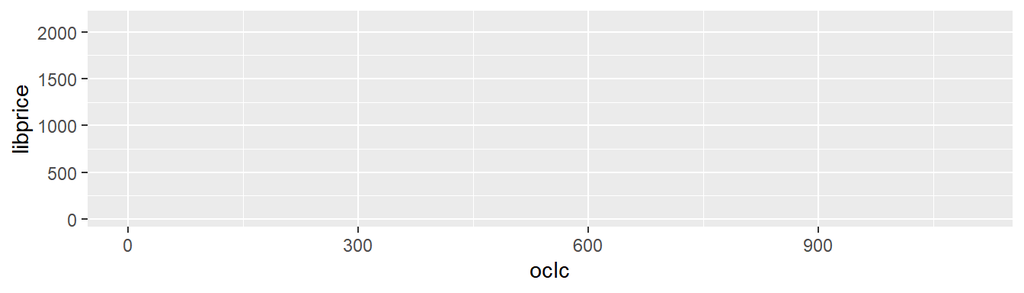

```r
ggplot(data = Journals) +
  aes(x = oclc, y = libprice)
```

**À ce stade, on visualise le canevas du graphique mais les données ne sont pas encore représentées**  
2. On ajoute une couche de géométrie pour dessiner les données (= type de graphique)

**Afficher le code**

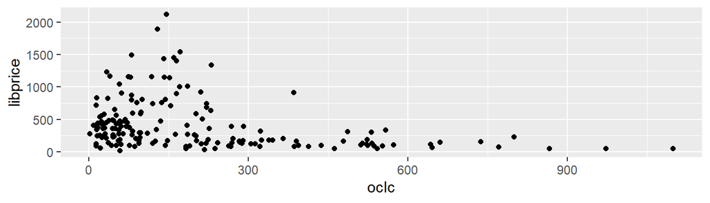

```r
# Nuage de points avec geom_point
ggplot(data = Journals) +
  aes(x = oclc, y = libprice) +
  geom_point()
```

**Avec `geom_*()`, les données sont représentées sur le graphique**  
3. On ajoute ensuite des couches pour ajuster la mise en forme du graphique

#### `aes()` : définir les paramètres esthétiques

On précise quelles variables contrôlent les propriétés visuelles du graphique

| *Aesthetic* | **Description** |
| --- | --- |
| x | variable en abscisse |
| y | variable en ordonnée |
| colour | couleur du contour (des points, lignes, etc.) |
| fill | couleur de remplissage (des points, formes, etc.) |
| size | taille des points, épaisseur des lignes |
| alpha | transparence |
| linetype | motif des tirets des lignes |
| shape | type de formes |

#### `geom_*()` : définir le type de graphique

**Principales geométries**

Les aspects esthétiques obligatoires sont indiqués en gras

| *Geometry* | **Description** | **Aspects esthétiques** |
| --- | --- | --- |
| `geom_point()` | Nuage de points | **x**, **y**, colour, fill, group, shape, size, alpha |
| `geom_bar()` | Diagramme en barres | **x**, **y**, colour, fill, group, linetype, linewidth, alpha |
| `geom_histogram()` | Histogramme | *identiques à `geom_bar()`* |
| `geom_boxplot()` | Boîte à moustaches | **x** OU **y**, **ymin** OU **xmin**, **ymax** OU **xmax**, colour, fill, group, linetype, linewidth, shape, size, alpha |
| `geom_density()` | Densité | **x**, **y**, colour, fill, group, linetype, linewidth, alpha |
| `geom_line()` | Courbe | **x**, **y**, colour, group, linetype, linewidth, alpha |
| `geom_text()` | Texte | **x**, **y**, label, colour, angle, group, hjust, lineheight, size, vjust, alpha |
| `geom_label()` | Texte | *identiques à `geom_text()`* + fill |

**Possibilité d’ajouter plusieurs fonctions `geom_*()` sur un même graphique**

L’ensemble des fonctions `geom_` est détaillé dans la *cheatsheet* {ggplot2}

[figure not shown]

[figure not shown]

**AstuceUne règle simple à retenir**

- **Ce qui se trouve dans `aes()` varie avec les données** = une variable détermine une esthétique
- **Les esthétiques placées en dehors de `aes()`, dans `geom_*()`, correspondent à un réglage fixe** = une valeur fixe règle l’apparence de la couche `geom_*()`

*Exemples*

**Afficher le code**

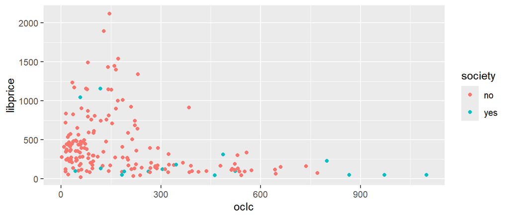

```r
# Points colorés selon les valeurs de 'society'
ggplot(data = Journals) +
  aes(x = oclc, y = libprice,
      colour = society) +
  geom_point()
```

**Afficher le code**

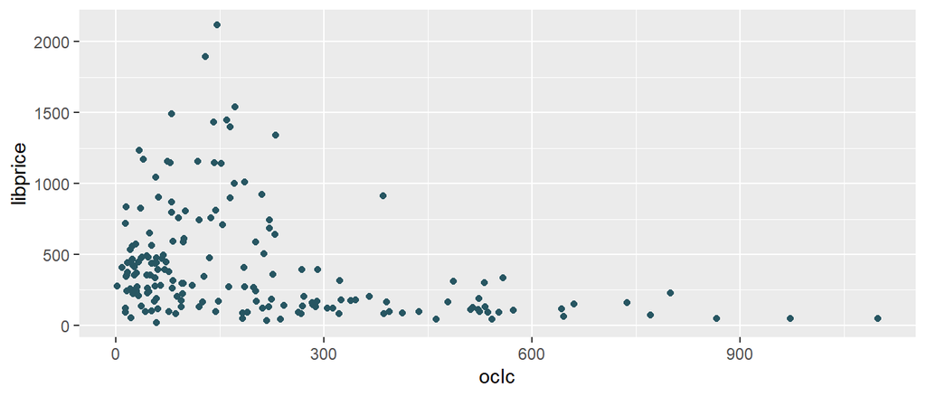

```r
# Points de couleur verte
ggplot(data = Journals) +
  aes(x = oclc, y = libprice) +
  geom_point(color = "#275662")
```

#### `stat_*()` : effectuer un calcul sur les données avant leur affichage

Ce qui est affiché sur le graphique : comptage, moyenne, etc.

**Principales fonctions**

| *Fonctions* | **Description** |
| --- | --- |
| `stat_identity()` | Données brutes, sans transformation |
| `stat_count()` | Comptage par modalité d’une variable catégorielle |
| `stats_bin()` | Découpage d’une variable continue en classes (*bins*) |
| `stat_summary()` | Résumé d’une variable pour chaque modalité d’une autre variable |
| `stats_boxplot()` | Calcul des statistiques de la boîte à moustaches (médiane, quartiles, moustaches) |
| `stats_sum()` | Comptage de points superposés |

*Exemple*

**Afficher le code**

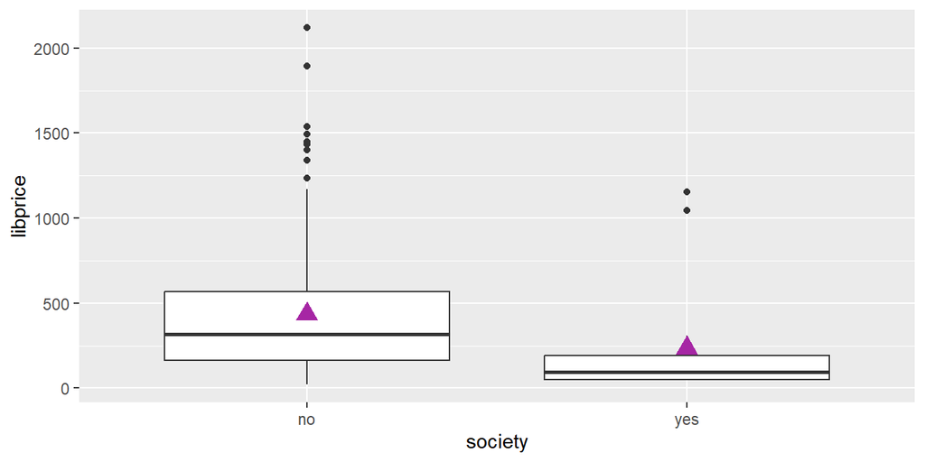

```r
# Affichage sur chaque boxplot
# de la moyenne de 'libprice'
ggplot(data = Journals) +
  aes(x = society, y = libprice) +
  geom_boxplot() +
  stat_summary(geom = "point",
               fun = "mean",
               colour = "#A626A4",
               shape = 17,
               size = 4)
```

#### Équivalences entre `geom_*()` et `stat_*()`

**Les deux sont souvent interchangeables, c’est une différence de point de vue :** `geom_*()` priorise la forme graphique (barres, points, lignes) ; `stat_*()` priorise la transformation statistique (comptage, résumé, etc.)

On peut reproduire le graphique précédent avec `geom_point()`

**Afficher le code**

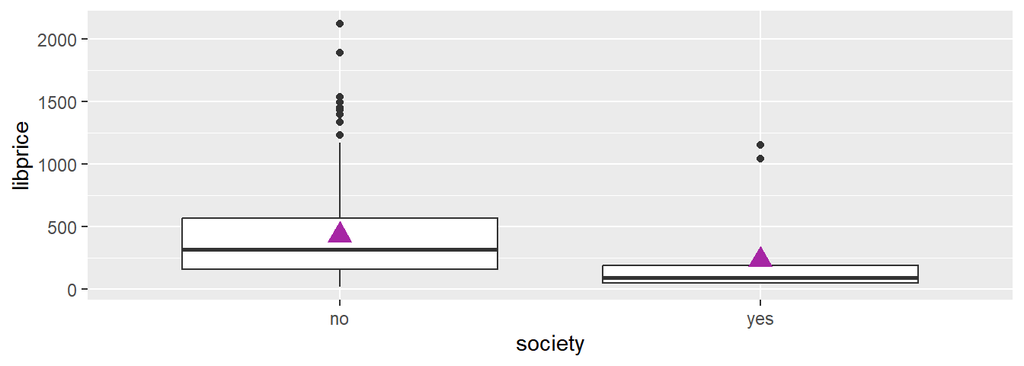

```r
ggplot(data = Journals) +
  aes(x = society, y = libprice) +
  geom_boxplot() +
  geom_point(stat = "summary",
             fun = "mean",
             colour = "#A626A4", shape = 17, size = 4)
```

**Principales correspondances**

| *Geometry* | *Statistics* |
| --- | --- |
| `geom_bar()` | `stat_count()` |
| `geom_histogram()` | `stat_bin()` |
| `geom_boxplot()` | `stat_boxplot()` |
| `geom_density()` | `stat_density()` |
| `geom_quantile()` | `stat_quantile()` |
| `geom_count()` | `stat_sum()` |
| `geom_dotplot()` | `stat_bindot()` |